# XGBoost Classification model

MAKINI CALEB

2026-10-01

# SETTING A WORKING DIRECTORY

```r
setwd("C:/Users/ADMIN/OneDrive/Desktop/caleb makini")
```

# loading libraries

```r
library(xgboost)
library(rio)
library(caret)
library(ggplot2)
library(dplyr)
library(rio)
library(pROC)
```

## LOAD DATA SET

```r
health_data <- read.csv("diabetes.csv")
head(health_data)
```

```
  age hypertension heart_disease smoking_history  BMI HbA1c_level
1  34            0             0           never 24.5         5.2
2  58            1             0          former 28.1         6.1
3  42            0             0         current 31.4         7.8
4  65            1             1          former 26.7         5.9
5  29            0             0           never 22.1         4.9
6  71            1             0           never 29.3         6.8
  blood_glucose_level diabetes
1                  89        0
2                 112        0
3                 145        1
4                  98        0
5                  82        0
6                 132        1
```

# check for missing values

```r
health_data <- na.omit(health_data)
colSums((is.na(health_data)))
```

```
                age        hypertension       heart_disease     smoking_history
                  0                   0                   0                   0
                BMI         HbA1c_level blood_glucose_level            diabetes
                  0                   0                   0                   0
```

# confirm for missing values

```r
colSums((is.na(health_data)))
```

```
                age        hypertension       heart_disease     smoking_history
                  0                   0                   0                   0
                BMI         HbA1c_level blood_glucose_level            diabetes
                  0                   0                   0                   0
```

# structure

```r
str(health_data)
```

```
'data.frame':   1099 obs. of  8 variables:
 $ age                : int  34 58 42 65 29 71 38 55 44 62 ...
 $ hypertension       : int  0 1 0 1 0 1 0 1 0 1 ...
 $ heart_disease      : int  0 0 0 1 0 0 0 1 0 0 ...
 $ smoking_history    : chr  "never" "former" "current" "former" ...
 $ BMI                : num  24.5 28.1 31.4 26.7 22.1 29.3 33.2 27.9 25.6 30.1 ...
 $ HbA1c_level        : num  5.2 6.1 7.8 5.9 4.9 6.8 8.5 6.3 5.4 7.1 ...
 $ blood_glucose_level: int  89 112 145 98 82 132 162 118 91 138 ...
 $ diabetes           : int  0 0 1 0 0 1 1 0 0 1 ...
 - attr(*, "na.action")= 'omit' Named int 1100
  ..- attr(*, "names")= chr "1100"
```

```r
table(health_data$diabetes)
```

```
  0   1
612 487
```

### convert categorical variables into factor

```r
health_data$diabetes <- as.factor(health_data$diabetes)
```

## split thye data set

```r
set.seed(123)
trainIndexed <- createDataPartition(health_data$diabetes, p = 0.8, list = FALSE)
train <- health_data[trainIndexed, ]
test <- health_data[-trainIndexed, ]
```

## one hot encoding variables

```r
dummy <- dummyVars(diabetes ~ ., data = train)
train_x <- predict(dummy, train)
test_x <- predict(dummy, test)
train_y <- as.numeric(as.character(train$diabetes))
test_y <- as.numeric(as.character(test$diabetes))
```

# create dmatrix

```r
dtrain <- xgb.DMatrix(data = train_x, label = train_y)
dtest <- xgb.DMatrix(data = test_x, label = test_y)
```

# train xgboost model

```r
params <- list(objective = "binary:logistic", eval_metric = "logloss", max_depth = 4,
    eta = 0.1, subsample = 0.8, colsample_bytree = 0.8)
xgb_model <- xgb.train(params = params, data = dtrain, nrounds = 100, watchlist = list(train = dtrain),
    verbose = 1)
```

### make predictions

```r
make_predictions <- predict(xgb_model, dtest)
predictions <- ifelse(make_predictions > 0.5, 1, 0)
```

# confusion matrix

```r
confusionMatrix(factor(predictions), factor(test_y))
```

```
Confusion Matrix and Statistics

          Reference
Prediction   0   1
         0 122   2
         1   0  95

               Accuracy : 0.9909
                 95% CI : (0.9674, 0.9989)
    No Information Rate : 0.5571
    P-Value [Acc > NIR] : <2e-16

                  Kappa : 0.9815

 Mcnemar's Test P-Value : 0.4795

            Sensitivity : 1.0000
            Specificity : 0.9794
         Pos Pred Value : 0.9839
         Neg Pred Value : 1.0000
             Prevalence : 0.5571
         Detection Rate : 0.5571
   Detection Prevalence : 0.5662
      Balanced Accuracy : 0.9897

       'Positive' Class : 0
```

- The Confusion Matrix (The Raw Numbers)A confusion matrix compares what the model predicted against the actual reference truth. The dataset has 219 total samples, split by the model like this: True Positives (122): The actual class was 0, and the model correctly predicted 0. True Negatives (95): The actual class was 1, and the model correctly predicted 1.False Positives (2): The actual class was 1, but the model incorrectly guessed 0.False Negatives (0): The actual class was 0, and the model never missed it.
- Overall Model Performance MetricsThese metrics evaluate how well the model works as a whole across all data points: Accuracy (99.09%): The overall success rate. The model guessed correctly 217 out of 219 times. 95% Confidence Interval (96.74%, 99.89%): A statistical range. If you ran this model on new, identical distributions of data, you can be 95% confident the accuracy would fall between these two percentages. No Information Rate / NIR (55.71%): The accuracy you would get by blindly guessing the majority class (Class 0) every single time. P-Value [Acc > NIR] (< 2e-16): A measure of statistical significance. Because it is essentially zero, it proves your model’s high accuracy is due to genuine predictive power, not random luck. Kappa (0.9815): Measures agreement between predictions and reality, adjusted for chance. A score above 0.80 is considered excellent; 0.98 indicates near-perfect reliability. McNemar’s Test P-Value (0.4795): Checks if the model’s errors are heavily biased toward one type of mistake over another. A high p-value (greater than 0.05) means your small number of misclassifications (just 2 errors) are statistically balanced.
- Class-Specific Metrics (Class 0 as ‘Positive’)Because Class 0 is designated as the target “Positive” class, the performance breaks down into specific dimensions of accuracy: Sensitivity / Recall (100.00%): Out of all actual Class 0 cases in the data, the model found every single one. It missed zero positive cases.Specificity (97.94%): Out of all actual Class 1 cases, the model correctly identified 97.94% of them. It only misclassified two.Balanced Accuracy (98.97%): The average of Sensitivity and Specificity. It gives an honest view of performance when classes are unevenly split.Positive Predictive Value / Precision (98.39%): When the model claims a sample is Class 0, it is right 98.39% of the time.Negative Predictive Value (100.00%): When the model claims a sample is Class 1, it is right every single time. -Data Split & PrevalencePrevalence (55.71%): The actual proportion of Class 0 in your entire dataset ($122/219$).Detection Rate (55.71%): The rate at which the model successfully found true positives relative to the total dataset size.Detection Prevalence (56.62%): The total proportion of the dataset that the model claimed belonged to Class 0, regardless of whether it was right or wrong ($124/219$).
- Formatting Styles ExplainedWhen putting this data into a final report, the writing changes drastically based on who is reading it: Academic / APA Style: Written for researchers, peer reviews, or journals. It relies heavily on parenthetical statistics, technical terminology, and exact numerical representations (e.g., “The classifier demonstrated a significant improvement over the baseline No Information Rate, χ²… p < .001…”). Business / Executive Style: Written for project stakeholders, managers, or clients. It strips away technical jargon (like Kappa or McNemar’s) and frames the numbers around risk and operational reliability (e.g., “Our system operates at a 99.09% success rate. Crucially, it has a 0% fail-miss rate for Class 0, meaning no critical targets are bypassed…”).

### ROC_CURVE

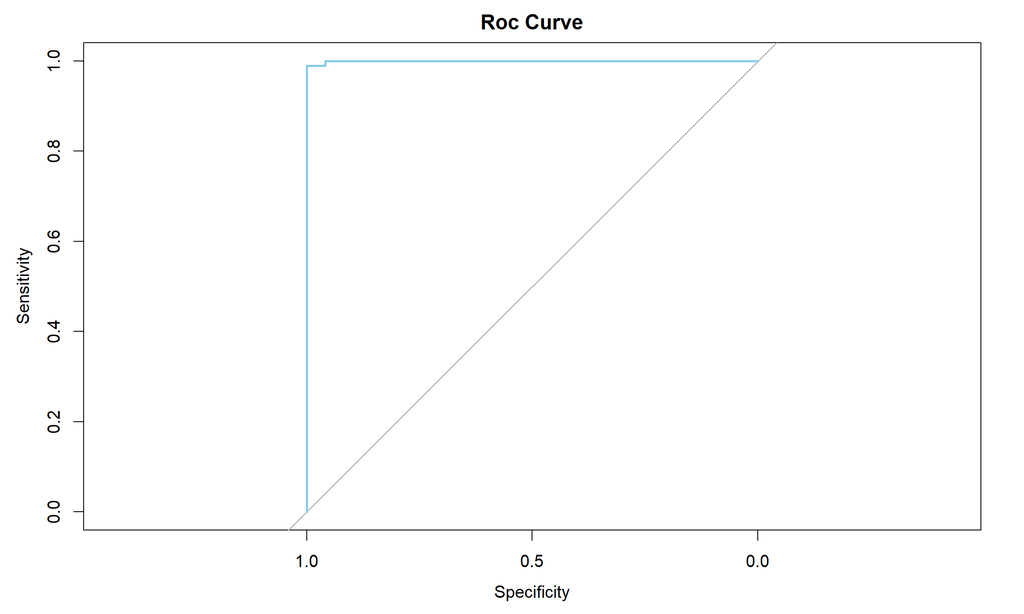

```r
roc_curve <- roc(test_y, make_predictions)
plot(roc_curve, col = "skyblue", main = "Roc Curve")
```

# visualize diabetes

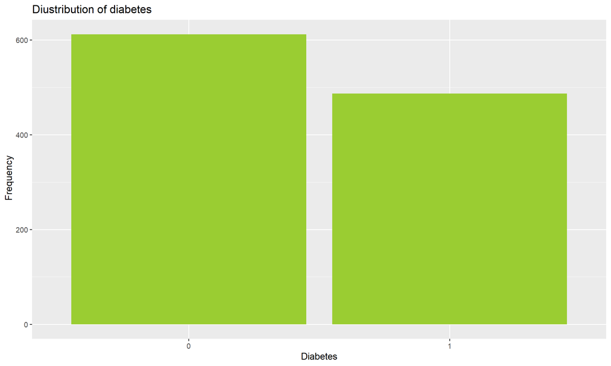

```r
ggplot(health_data, aes(x = factor(diabetes))) + geom_bar(fill = "yellowgreen") +
    labs(title = "Diustribution of diabetes", x = "Diabetes", y = " Frequency")
```